[figure not shown]

[figure not shown]

# Introduction

The technological revolution gave us the power to track kid’s appropriate growth with the age and helps to choose essential food habits and induce exercise habits in daily routine for ideal development. Growth refers to both mental maturation and physical development. Mental and physical development of kids depends on many factors like height, weight, type of food consumed, pulse, blood pressure, exercise duration, sleep time, etc. Out of these mentioned factors few can’t be controlled which are mostly natural and genetic.

Weight can be partially controllable and plays a significant role in children’s growth. Therefore, the weight has been considered as one of the most important factors which need to be monitored for the proper growth of the children. In this report, a general weight change trend with the increase in age has been created and analyzed to find out any anomalies in the growth for both boys and girls separately.

[figure not shown]

Every kid has diverse changing patterns of weight with an increase in age. But inconsistent weight increase can adversely affect confidence, mental growth, and in the long run can increase the risks of type-2 diabetes and cardiovascular disease, which can further affect psychological well-being.

Obesity and psychological disorders are unsurprising: weak self-image, physical inactivity, obesity-induced biological disturbance, and overweight societal discrimination all lead to mental impairment predisposition. Depression and poor self-esteem were observed in obese patients all over the world, even though no prior evidence of mental disease has been identified. The Texas Health Science Center5 and the National Obesity Observatory of the United Kingdom (NOO) are among the many research institutions that confirm that obesity causes a higher risk of depression (Mary Gatineau (2011)). A patient’s age and gender can decide the strength of the association between obesity and mental illness. Research undertaken by Dr van der Merwe in South Africa showed that once obese, young women were at a higher risk for mental illness as compared to the men. The researcher postulated that this is because women seem to be more depressed by the idea of overweight than men, making them more vulnerable to mental illness. (Merwe (2007)).

Most research on obesity or skinniness and the causes of such substantial weight changes in youth-centered are the functions of proximate determinants of weight gain (e.g., Prolong Television watching and meals away from home) and their direct determinants. Further distal factors that cause shifts in these near and similar determinants have been granted with less consideration. Considering the lack and limited or non-results of studies into prevention and treatment of obesity in youth, the focus on more distal determinants can be of assistance in recognizing teenagers who are at risk and can offer insight into possible goals for the next round of study to tackle obesity or skinniness.

With the daily busy lifestyle sometimes it’s usual for the parents to lose track of their kid’s weight changes, which is very important to monitor to ensure kid’s significant growth. Hence, weight change should be tracked properly at every age and even a slight deviation in weight change from the general weight trend can indicate an abnormality in kid’s growth which can indicate consultation.

Several research and studies were carried out to find the factors behind kids’ abnormal BMI categories. But there is very little awareness and investigation that has been done to find the kids’ general weight change trend with the increase in age. Discovering the general weight change trend for teenagers can be a great help to find out any sudden shift in weight with age for any particular children and eventually the kids can be controlled to be moved towards any abnormal BMI Categories i.e, overweight, obese, thin or severely thin. Besides, it can also assist in monitoring prolonged weight change of the adolescent and can help to estimate or predict the BMI category in the future and can prefer consultation if required.

Hence, the goal of this analysis is to examine the weight changes of teenagers with an increase in age. I used a sample dataset, which consists of 6–18 years of kids whose anthropometric parameters were measured from 2007-2018. In the next section, I have presented a conceptual framework to understand why finding the general weight change pattern of teenagers (separately for both boys and girls) is important. In the following sections, I have discussed the background literature, data used, and showed some preliminary analysis. After that, I will discuss on the shinny app developed for visualizing the weight change of all the kids and the methods used for finding the general weight trend followed by an elaborated discussion on results which includes, the counts of BMI abnormalities with age, model selection, checking model performance and overall results. Finally, to conclude, I will discuss the reason behind any differences found in weight change for both boys and girls with an increase in age.

# Background

Modernization and technological advancement have evolved our lifestyle enormously giving wings to our desire and expanded our reach worldwide. Technology reduced our efforts in many ways, online shopping relaxes the effort of going to a supermarket, social networking helped people to communicate or interact with family members or friends virtually even they are on the other side of the globe. But there are adverse effects as well of this modernization. Online gaming serves the privilege of identical feeling and excitement as a real game which somehow reduced the effective exercise time and physical efforts by the kids, which is very necessary to keep the children fit, healthy, and also nurture for the proper mental and physical growth.

The incidence of the overweight rate among 12-19-year-old rose from 5.0% to 15.5% between 1976–80 and 1999–2000 by more than three-fold. For non-Hispanic black teens and Mexican American adolescents, particularly boys, this trend towards increased obesity has been significantly higher(Cynthia L. Ogden and Carroll (2002)). The increase in the weight of teenagers may be very severe. Primarily, bigotry and stigmatic behavior can be identified against overweight or obese individuals and teenagers (Schwartz and Puhl (2003))(Strauss and Pollack (2003)). Besides, weight issues also contribute to severe adolescent health risks, such as asthma, obesity, the resistance of caffeine, hepatic steatosis, and orthopedic complications. There is also a high risk of an overweight child becoming overweight or obese adults which can cause socio-economic disadvantages like low wages as compared to others.

There are so many negative aspects associated with obesity. But all these issues can be avoided if necessary precautionary measures are taken at the point when a kid’s weight deviates from normal trend (e.g: normal to overweight or normal to thin). Therefore, to understand or identify the deviation towards abnormal weight patterns of the kids, we should be aware of the normal weight change pattern with age. In this report, I analyzed the data and tried to find a general weight change curve for boys and girls separately.

# Data

The data used for the analysis is taken from three Hungarian cities (Hódmezővásárhely, Mártély, and Mindszent), in southern Hungary over a period of 12 years (2007-2018) and measurements for each participant was taken twice a year (April and October). The dataset contains anthropometric parameters (age, height, weight, BMI, etc) and consists of 1,02,642 numbers of records of a large 14,267 participants aged between 6–18 years cohort(Katalin Havasi and Bereczki (2020)). The BMI was calculated using the formula:

$$\begin{equation}
BMI = weight / height^2
\end{equation}$$

Z-score represents the number of standard deviations of an anthropometric measure below or over the mean or median reference point. Among children of a certain generation, a set z-score interval means a defined height or weight distance. For population-based applications, it is critical that summary stats like mean and standard deviations can be provided in a group of z-scores.

The z score has been calculated from the WHO methodology and it can be calculated by the formula:

$$\begin{equation}
zscore = (X-m)/SD
\end{equation}$$

Where, X is the measured value (height, weight, or BMI), m is the mean, and SD is the standard variance deviation of the distribution of the sample population. Both m and SD vary with gender and age. The Z-Categories are selected as per the z-score which were determined according to the rules set by WHO (Antonio Martinez-Millana and Ribes-Koninckx (2018)).

The dataset contains many NA values that were removed to avoid calculation difficulties. Besides, there were inaccurate formatting seen in the variables which were rectified and corrected. The ID, z category, and gender variables were converted into factors. Also, three new variables were added for calculation easiness which is year, age_mod, and observation showing only a year, modified rounded age, and the observation number respectively.

**Data Exploration**

A glimpse of the dataset used is as follows:

|  | ID | measurement_date | age_years | age_bin | gender | height_cm | weight_kg | BMI | z_score_WHO | z_cat_WHO | observation | year |
| --- | --- | --- | --- | --- | --- | --- | --- | --- | --- | --- | --- | --- |
| 1 | 1 | 2011-10-01 | 15.07283 | 15 | boy | 174 | 70 | 23.12062 | 1.1231024 | overweight | 1 | 2011 |
| 2 | 1 | 2012-04-01 | 15.57283 | 15 | boy | 174 | 70 | 23.12062 | 1.0012929 | overweight | 2 | 2012 |
| 3 | 1 | 2012-10-01 | 16.07283 | 16 | boy | 174 | 72 | 23.78121 | 1.0708747 | overweight | 3 | 2012 |
| 4 | 1 | 2013-04-01 | 16.57283 | 16 | boy | 174 | 66 | 21.79944 | 0.3498330 | normal | 4 | 2013 |
| 5 | 1 | 2013-10-01 | 17.07283 | 17 | boy | 173 | 67 | 22.38631 | 0.4346262 | normal | 5 | 2013 |

The variables in this dataset are:

**ID:** Unique identification number of the participant.

**measurement_date:** Date when the measurement was taken.

**age_year:** Age measured in years.

**age_bin:** Age in a rounded figure in years.

**gender:** Gender of the kid which is a factor (boy or girl).

**height_cm:** Height of the kids in cm.

**weight_kg:** Weight of the kids in kg.

**BMI:** BMI of the kids.

**z_score_WHO:** Z score of the kids.

**z_cat_WHO:** Z category of the kids which is a factor (normal, thin, severely thin, overweight and obese)

BMI Category is composed of height and weight, where height increase with age is genetic and can’t be controlled but on the other side, weight increase depends on many factors and can be controlled by taking necessary measures to maintain normal BMI or Z-Category. Hence, the main objective of this analysis is to compare the weights of boys and girls over a specified period (2007-2018). Also, to find out an overall weight change pattern with the increase in age and further, to detect if there are any anomalies present in the weight change for any specific kid and if present, then, to suggest a consultation. And to point out if there are any differences in the overall weight change curve for boys and girls and to investigate the reason behind it. Besides, to find out the weight range when both boys and girls are most likely or vulnerable to deviate from normal BMI or Z-Category.

# Preliminary Analysis

The dataset consists of records of more than 14000 individuals and measurements of them were taken for almost 12 years (2007-2018). The records were taken for kids aged between 6 to 18 years. Therefore, all the individuals don’t have their reading of measurements taken throughout from 2007 to 2018, because if a kid is aged 12 at the year 2007 when his measurements were recorded, his data will be recorded till he reaches the age 18, i.e., till the year (2007+(18-12) 2013 and after 2013 there will be no record for this particular kid. Similarly, if another kid is of age 7 in the year 2007, his data will be taken till he reaches 18 years of age i.e., (2007+(18-7)) 2018. It is evident that even if there are more than 14000 individuals, not everyone’s measurements were taken throughout from 2007 to 2018. Hence, for analyzing the weight changes precisely it is necessary to consider only those kids whose measurements were taken every year and use only those records for model building.

To find out the kids whose data were recorded from 2007 till 2018, a common subset of ID has been taken out by comparing the data of each consecutive year and a set of kids ID has been recognized whose measurements were taken as per the requirement i.e., 2007-2018. A total of 141 participants were identified and found eligible for the analysis who has been continuously measured throughout 2007-2018. After that, as per the ID, all the associated records corresponding to those IDs were filtered out. These 141 participants had 3002 records which were taken each year from 2007 to 2018 and are used for model building and analysis.

A few records and the parameters of the dataset are shown below:

|  | ID | measurement_date | age_years | age_bin | gender | height_cm | weight_kg | BMI | z_score_WHO | z_cat_WHO | observation | year | age_mod |
| --- | --- | --- | --- | --- | --- | --- | --- | --- | --- | --- | --- | --- | --- |
| 1 | 129 | 2007-10-01 | 7.253653 | 7 | girl | 122 | 25 | 16.79656 | 0.7228241 | normal | 1732 | 2007 | 7.0 |
| 2 | 129 | 2008-04-01 | 7.753653 | 7 | girl | 125 | 27 | 17.28000 | 0.8569487 | normal | 1733 | 2008 | 7.5 |
| 3 | 129 | 2008-10-01 | 8.253653 | 8 | girl | 131 | 29 | 16.89878 | 0.5749299 | normal | 1734 | 2008 | 8.0 |
| 4 | 129 | 2009-04-01 | 8.753653 | 8 | girl | 132 | 30 | 17.21763 | 0.6040327 | normal | 1735 | 2009 | 8.5 |
| 5 | 129 | 2009-10-01 | 9.253653 | 9 | girl | 132 | 31 | 17.79155 | 0.7253649 | normal | 1736 | 2009 | 9.0 |

For the initial investigation, it is vital to check the weight change pattern of 141 participants with an increase in age. The graph of weight change with the increase in age has been plotted for boys and girls separately to point out any differences.

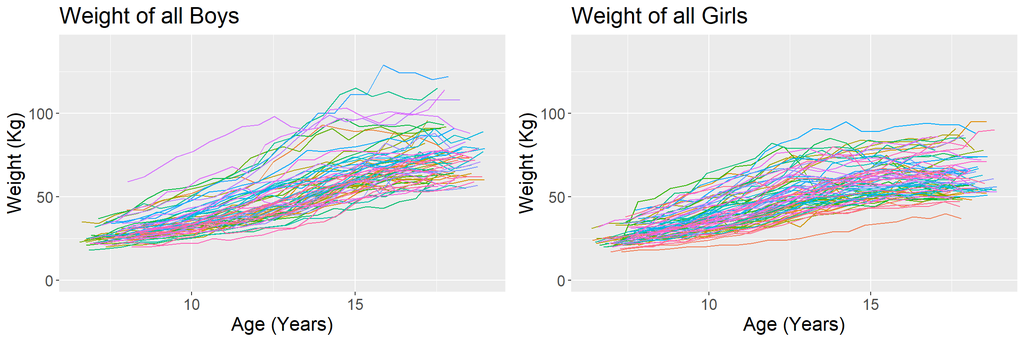

Weight Change of all 141 kids with age

From the above plots, it can be observed that at ages 6 and 7 most of the boys’ weight ranges approximately below 27kg while for girls the range is between 15kg to 35kg. Although both boys and girls have almost constant weight increase rates, it can be seen that after the initial few ages (age 6 to 9) boys’ weight increase is more as compared to girls. Hence, as a preliminary analysis, we can roughly assume from this visualization that boys are comparatively heavier than the girls at the same age level.

# Shiny App

In the previous preliminary visualization section, we have considered 3002 records from 141 participants. But there may be a requirement to check the weight changes for other participants as well. The shiny app is a good way to visualize the output as per the input. In this Shiny app, all the 94704 records from 14,267 participants were considered.

The structure of the Shiny app is designed in the way that, it will show the weight changes with the increase in age and will also indicate any changes in the Z-category (e.g: Normal, Obese, Thin, etc.) concerning the initial stage. The input fields in the Shiny app are Gender, Z-Category change from the initial stage, and ID. In case the ‘Gender’ or ‘Z-Category change from initial stage’ is not known can be selected as ‘Not Known’ and the ID can be entered directly in the ID input space. In another situation, if there is any requirement to compare BMI or Z-Category changes of multiple IDs or kids, that can be achieved by selecting those IDs and in the output space Z-Category changes for those selected IDs will be displayed with different colors pointing out specific IDs or kids.

## Gender Input Space

In the Gender input space, the valid fields which can be selected are Boy, Girl, or Not Known. In a typical situation, if the user is now aware of the gender he can select the gender as ‘Not Known’ and the next input space will consider all boys’ and girls’ IDs. If a boy is selected as gender only the boy’s IDs will be considered for the next input selections and will appear on the ID input space.

[figure not shown]

Shiny App: Change of Z category with Z score(Gender Selection)

## Z-category change from initial stage Input Space

There are five different BMI categories or Z-Categories depending on the Z-scores. The different Z-categories are:

- Obese
- Overweight
- Normal
- Thin
- Severely Thin

In this input space, the selection should be done based on the number of changes in Z-Category from the first observed Z-Category. If the changes in Z-Category are unknown to the user ’ Not Known’ can be selected and it will consider all Z-Category changes in the next input space. The valid selections in this input space are as follows:

- Not Known - BMI or Z-Category change is unknown.
- No Category Change - There is no BMI category change from the first observed BMI category or Z-Category.
- One Category Change - There is only one BMI category change from the initial stage. E.g: If a kid’s first observed BMI category is normal and the kid was been in the overweight category and later come back to normal weight category with age, then it is considered as One Category Change, as it has been to one of the other BMI categories except the initial BMI category.
- Two Category Change - There is two BMI category change from the first observed BMI category or Z-Category.
- Three Category Change - There is three BMI category change from the first observed BMI category or Z-Category.

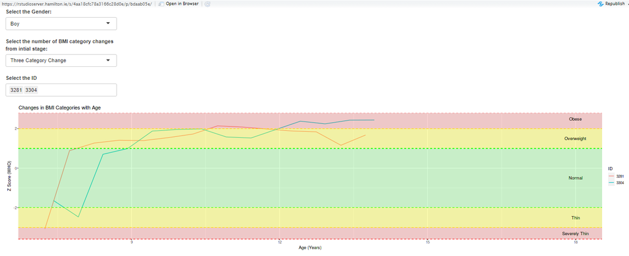

Shiny App: Change of Z-Category with Z-Score(BMI or Z-Category Change Selection)

## ID Selection Input Space

After gender and the BMI category change input space, in this input space ID need to be selected or can be written manually. If there is a requirement of comparing Z-Category changes of multiple kids, multiple IDs can be selected.

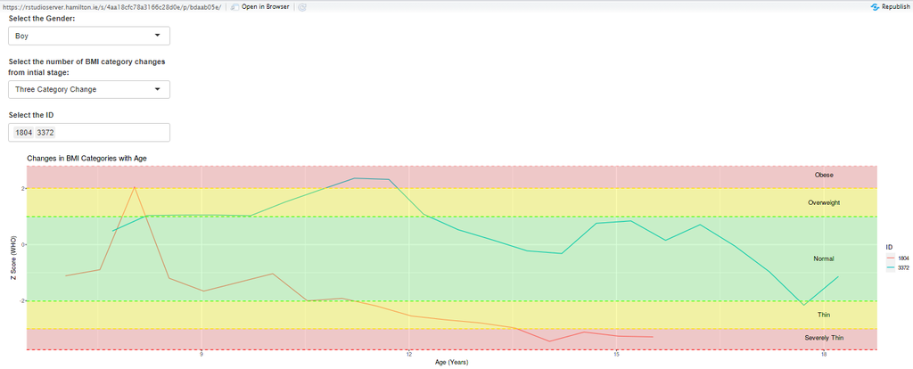

Shiny App: Change of Z category with Z score(ID Selection)

The different colored regions in the graph refer to how the Z-category is changing with an increase or decrease in Z-score(WHO).

## Kids with big changes in Z-Category

Here, the kids with maximum changes in Z-Category (three category change from the initial stage) has been identified and their Z-category change has been analyzed from the initial year to the final year i.e, 2007-2018.

**BOYS**

[figure not shown]

Z-Category Change for Boys with ID 3281 and 3304

It can be seen that the initial Z-Category for ID 3281(Red) and 3304(Green) were severely thin and normal, but with an increase in age both the kids have an increased trend in Z-score and eventually turned into overweight(3281) and obese(3304). Therefore, it can be assumed that there is a high chance for the kid(3281) to become obese in the future if necessary consultation is not taken.

[figure not shown]

Z-Category Change for Boys with ID 1804 and 3372

Similarly, for both ID 1804(Red) and 3372(Green), the initial stage or Z-category was normal, but there are multiple category changes for both of them with the increase in age. The ID 1804 has been drifted to the obese category before finally came down to a severely thin category, while ID 3372 has also been shifted to the obese category but eventually came to the normal followed by thin category.

**GIRLS**

In the case of girls, 940, 1072, 1699, and 11520 are the IDs showing big Z-Category changes.

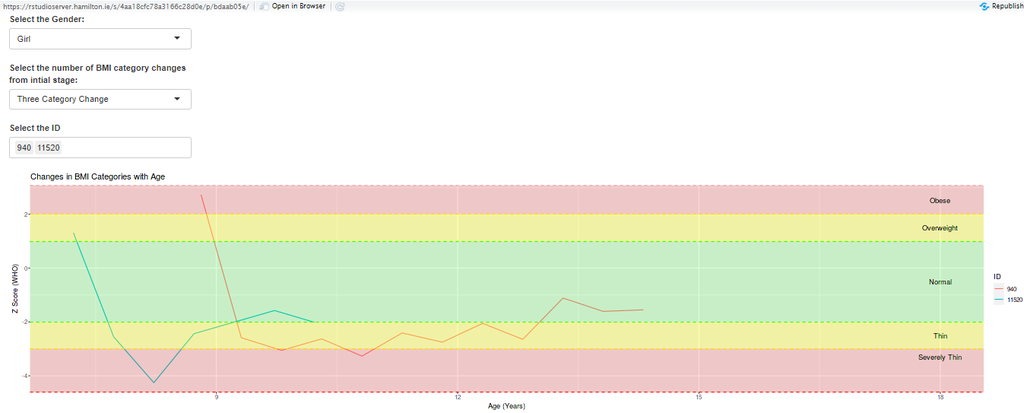

Z-Category Change for Girls with ID 940 and 11520

The kids with IDs 940(Red) and 11520(Green) have their initial Z-Categories as obese and overweight respectively but both shifted to the normal category in their final stage. It can be observed that both the kids have been overweight, severely thin, and thin categories before switched in the final normal stage.

[figure not shown]

Z-Category Change for Girls with ID 1072 and 1699

The kids with IDs 1072(Red) and 1699(Green) have initial stages thin and normal respectively. The final stage for the kid with ID 1072 is normal but this kid has been to thin, severely thin, and obese categories as well before her final normal Z-Category, while the girl with ID 1699 was been into thin and overweight categories before being her final obese stage. Therefore, it is highly recommended for the kid with ID 1699 to consult a specialist and follow medication if required.

**Shiny App URL:** https://sankhadip.shinyapps.io/thesis_shiny/

# BMI Abnormality Detection

## Detecting BMI abnormalities with Age

The dataset used for model building and analysis consists of 3002 records from 141 participants and measurements for all participants were taken consistently from 2007 to 2018. Therefore, each participant was at age 6 or 7 at the beginning of this study (2007). In this section, it has been tried to find out at what age kids are more likely to deviate from normal to abnormal BMI range, which can be thin, overweight, obese, or severely thin.

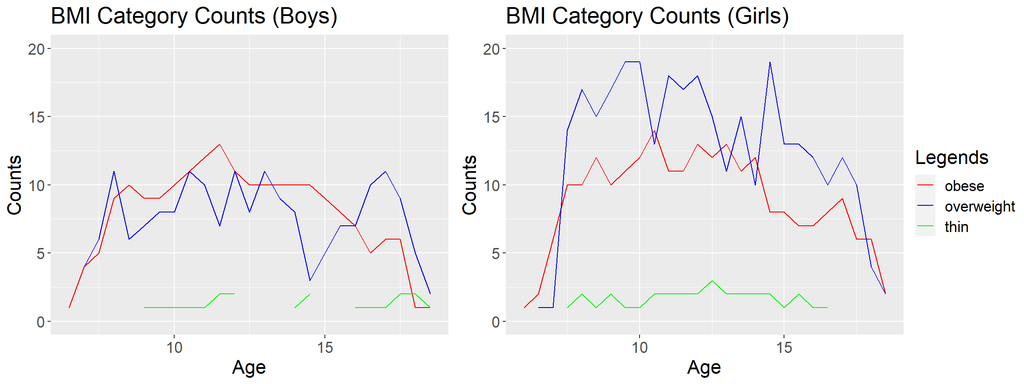

Abnormality in BMI Categories with Age (Boys and Girls)

The above plot shows the different abnormal BMI categories and their overall counts with age for 141 participants (boys - 65 and girls - 76). It can be implied that both boys and girls have a high tendency to become overweight and obese, a very small chance of being thin and almost no chance of being a severely thin kid.

Girls plot reveals different BMI category patterns than boys. From the girls’ plot, we can discover that girls are more tend to become overweight than to face obesity. The graph shows that during age 7 to 12 girl tends to become deviated from normal BMI category to overweight. There is an immediate spike in the overweight curve during age 14.5 to 15 as well. Similarly like overweight patterns, there are numbers of girls who are very likely to become obese during the age range 7.5 to 13 and a gradual decrease in the obese pattern after that can be seen. Girls also have the same pattern of thin BMI category as boys, with very less number of girls became thin during these 12 years.

## Total Count of BMI Abnormalities with Age

The total count of BMI abnormalities represents the total number of overweight, obese, thin, and severely thin categories with an increase in age. The total counts of abnormalities have been summed with age and has been plotted below. This represents the total number of deviations from the normal BMI category with age.

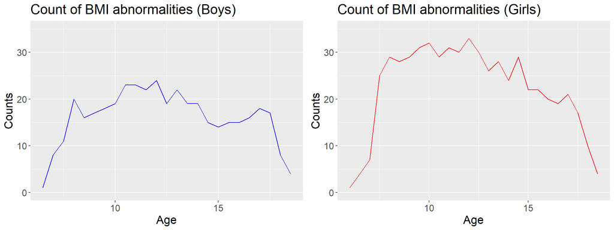

Number of Overall BMI abnormalities with Age (Boys and Girls)

It is clearly visible that girls are more likely to drift from normal weight status at any point in time. Approximately, during ages 10 to 12, there are high chances for boys to become shifted from normal BMI range and to become overweight, obese, or thin. There are also small spikes of increased abnormal BMI category patterns during the age of 7.5 to 8 and 16.5 to 17 as well. On the other hand, girls are more tend to diverge from their normal BMI category during the age range of 7.5 to 12.5.

# Methods

Several suitable methods are available for model building for these kinds of datasets, but the Generalized Additive Model (GAM) is preferred for model building and analysis. Generalized Additive Model (GAM) is quite flexible because there are no assumptions of the forms of the relationships between the response and predictors.

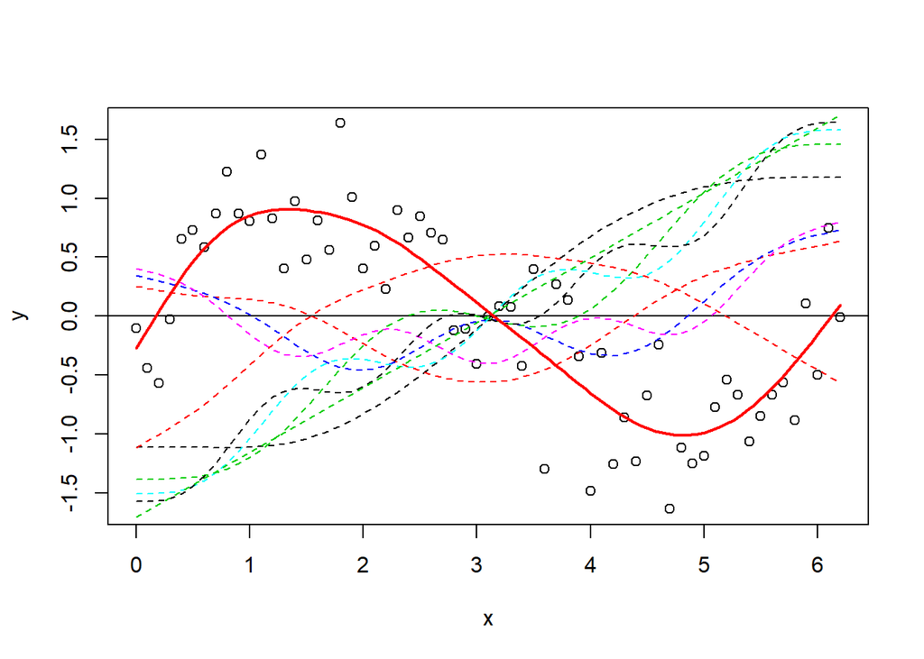

Functions $f_i$ may be functions of a given parametric type (for example, a variable’s polynomial or unpenalized regression spline) or maybe defined non-parametrically, or semi-parametrically, simply as ‘smoothing functions’ to be calculated by non-parametric means. For a standard GAM a smoothing function, like a local weighted mean, might use a scatterplot function for $f_1(x_1)$ and instead use a control factor for $f_2(x_2)$. This versatility, which allows it possible to conform non parametrically to the true relationship between response and prediction, gives the possibility for increased data adaptation, albeit with some lack of interpretability, when compared with parametrical models.

Gam uses smoothing terms to provide non-linear model fitting, hence gam is used for model building for this dataset. A GAM model can be implemented with two different functions i.e., gam() and bam(). These functions are largely similar but the most significant difference is that bam() is an optimized version of gam() and is preferable for large datasets. Therefore, bam() is used for model building and this function is from the ‘mgcv’ package(Wood (2019)).

Smoothing terms:

There are three different smoothing functions are available for modeling a potentially nonlinear smooth or surface. s() can be used for modeling a 1-dimensional smooth or isotropic interactions which mean variables are measured in the same units and on the same scale). te() is used for modeling 2- or n-dimensional interaction surfaces of variables that are not isotropic and also includes ‘main’ effects. And for modeling 2- or n-dimensional interaction surfaces that do not include the ‘main effects’ ti() can be used.

The parameters of smoothing functions: The smoothing functions have several parameters that could be set according to the change in parameter behavior. The most important and often-used parameters are listed here:

k: number of ‘knots’. This parameter determines the upper bound of the number of underlying base functions being used to build up the curve. Thus, this parameter constrains the wiggliness of a smooth, or - as a metaphor - the number of bow points of a curve. By default, the value of k for s() is around 9, and for te() and ti() 5 per dimension. Importantly, the value of k should be at most one less than the number of unique data points, otherwise, it will fit the density of that predictor.

d: It is used for specifying that predictors in the interaction are on the same scale or dimension (only used in te() and ti()). For example, in te(Time, width, height, d=c(1,2)), with width and height reflecting the picture size measured in pixels, we specify that Time is on a different dimension than the next two variables. By default, the value would be d=c(1,1,1) in this case.

bs: This specifies the type of underlying base function. For s() this defaults to “tp” (thin plate regression spline) and for te() and ti() this defaults to “cr” (cubic regression spline). For random intercepts and linear random slopes bs=“re” can be used, but for random smooths bs=“fs” is used.

Setting up a GAM model:

We have started with the age and height as predictors initially and used random effects to increase the model performance. Three different types of random effects are distinguished when using GAMs:

1. random intercepts effect - It adjusts the height of other model terms with a constant value: s(ID, bs=“re”).
2. random slopes effect - It adjusts the slope of the trend of a numeric predictor: s(ID, age, bs=“re”).
3. random smoothing effect - It adjusts the trend of a numeric predictor in a nonlinear way: s(age, ID, bs=“fs”, m=1).

The bs generate the B-spline basis matrix for a polynomial spline and specifies the type of underlying base functions and besides, ID is a factor which is also considered as a group.

The Random intercepts and random slopes could be combined, but the random smooths already include random intercepts and random slope effects. The argument m=1 sets a heavier penalty for the smooth moving away from 0, causing shrinkage to the mean. Here we are using bam as gam takes a longer time for huge datasets. Bam is a similar and optimized version of gam for huge datasets.

The dataset contains timely measured non-negative data where measurement has been taken in scheduled intervals, therefore, Gamma is used as a regression family. It has also been found that Gamma($link = "log"$) has given more satisfactory results as compared to normal Gamma family in terms of test errors and AIC. Hence, Gamma($link = "log"$) is preferred in the final model selection.

# Results

## Model Selection

Several models were fitted to weight separately genderwise for verifying the model performance and the data has been trained in the training dataset and fitted on the test dataset for checking the test error. The model which has the lowest test error has been considered as the best model and used for analysis. AIC value and K fold cross-validation method with 7 folds has been used for this purpose.

Model-1: $weight = age + height + s(ID, bs="re") + s(ID, age, bs="re")$

Model-2: $weight = age + height + s(age,ID,bs="fs",m=1)$

| Model | Score | Edf | Difference | Df | p.value | Sign. |
| --- | --- | --- | --- | --- | --- | --- |
| model3_b | -1240.560 | 5 |  |  |  |  |
| model4_b | -2052.007 | 5 | -811.447 | 0.000 | NA |  |

Therefore, from the two models discussed above I will prefer Model-2: $weight = age + height + s(age,ID,bs="fs",m=1)$ for further analysis of the data. The model for girls also show the same results like boys.

For validating the model performance, residual vs fitted values plot, Effects plot, Deviance Residuals and Theoretical Quantiles, & Residual histogram Plot can also be observed.

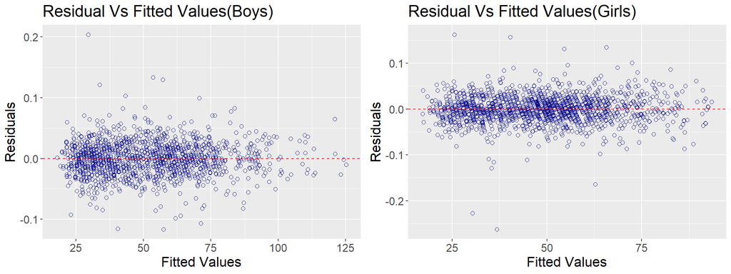

Residuals Vs Fitted Values Plot

From the above plot, it is visible that the residuals are randomly scattered over the mean zero lines, which is expected.

**Smoothing Effects Plot:**

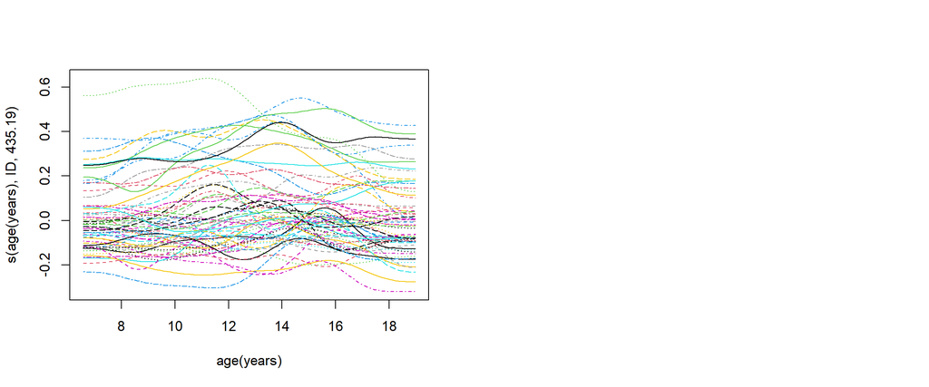

Smoothing Effects Plot

The above plot shows the change of smoothing function of age taking ID as a group with respect to the increase in age.

**Deviance Residuals and Theoretical Quantiles & Residual histogram Plot:**

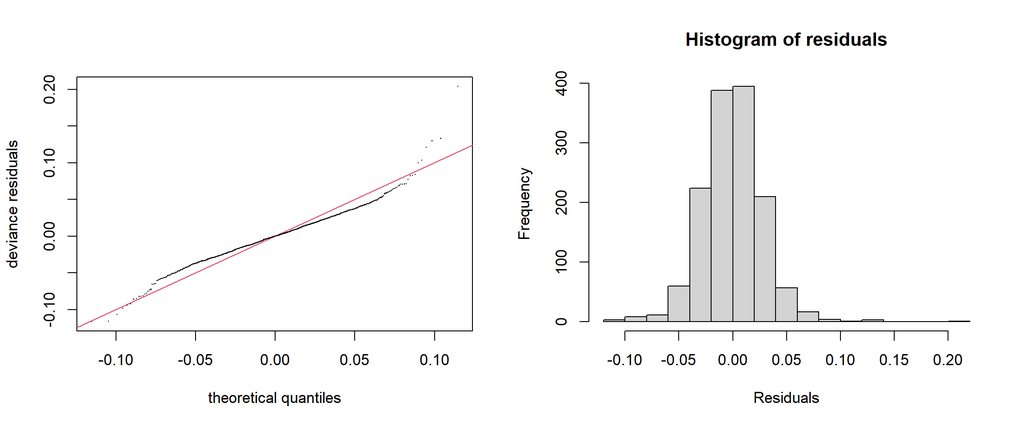

Deviance Residuals and Theoritical Quantiles & Residual histogram Plot

```
##
## Family: Gamma
## Link function: log
##
## Formula:
## weight_kg ~ age_years + height_cm + s(age_years, ID, bs = "fs",
##     m = 1)
##
## Parametric coefficients:
##              Estimate Std. Error t value Pr(>|t|)
## (Intercept) 1.6552456  0.0579577   28.56   <2e-16 ***
## age_years   0.0458988  0.0033513   13.70   <2e-16 ***
## height_cm   0.0101096  0.0005274   19.17   <2e-16 ***
## ---
## Signif. codes:  0 '***' 0.001 '**' 0.01 '*' 0.05 '.' 0.1 ' ' 1
##
## Approximate significance of smooth terms:
##                   edf Ref.df     F p-value
## s(age_years,ID) 435.2    584 52.51  <2e-16 ***
## ---
## Signif. codes:  0 '***' 0.001 '**' 0.01 '*' 0.05 '.' 0.1 ' ' 1
##
## R-sq.(adj) =  0.992   Deviance explained = 99.5%
## fREML =  -2052  Scale est. = 0.0011564  n = 1381
```

The summary of the final model shows that all the parametric and smoothing terms are significant. Also, the R-square value is 99.2% and deviance explained in 99.5%. Therefore, it is clear that this model is performing quite well. The model for girls also shows similar results.

## Model Performance

In model building, mainly age and height have been used as predictors except for the random and smooth effects. Visualizing the model fitting for the data is not possible or visually appealing when more than one predictor is used for model building. Therefore, using “mgcv” package(Wood (2019)) bam model is fitted with only age predictor along with the smoothing terms and used for visualizing the model fitting. The data for boys has been divided into 75% training and 25% testing. The model (with only age predictor, and smoothing effect) is fitted (trained) on the training data and performance has been checked on the test data. Similar steps have been followed for the girl’s data as well.

**Boys**

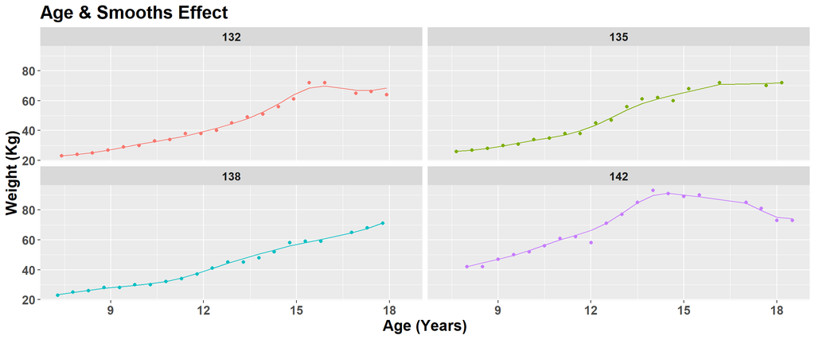

Fitted Model Validation (Boys)

**Girls**

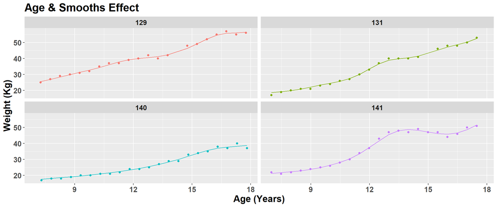

Fitted Model Validation (Girls)

Four random IDs have been selected from the test dataset for both boys and girls to visualize how the model is fitting the data. It can be observed from the above plot that the model is fitting the data quite perfectly.

## Overall Results

The main objective was to find out an overall weight trend curve for both boys and girls separately. The mean has been computed for both the actual and predicted weight variables and plotted with an increase in age for all the kids whose measurements have been taken thoroughly from 2007 to 2018.

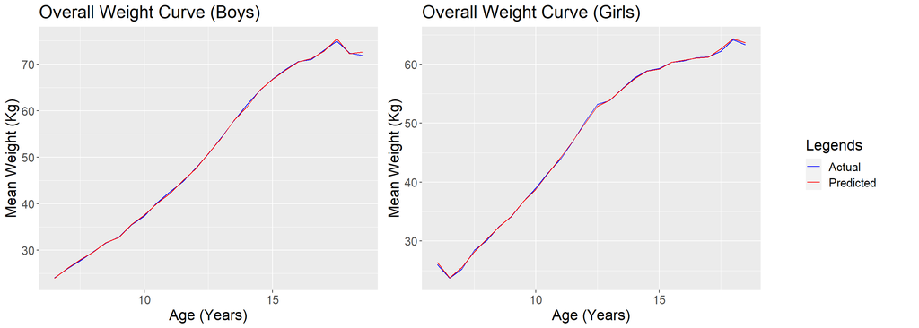

Overall Weight Change Trend with Age